# Tugas-Pertemuan-6

Daffa Kyanfaiza G1401231078

2025-10-09

```r
library(readxl)
```

```r
library(ggplot2)
library(tsibble)
library(tseries)
library(MASS)
library(forecast)
library(TSA)
library(graphics)
library(TTR)
library(aTSA)
```

# LOad Dataset

```r
data <- read_excel("D:/KULIAH/SEM 5/MPDW/laporan_iklim_harian-250831182901.xlsx")

dataset <- data[125:250, ]
dataset$TAVG <- as.numeric(dataset$TAVG)
dt1 <- ts(dataset$TAVG)
```

```r
mean <- mean(dt1, na.rm = TRUE)
mean
```

```
## [1] 26.87619
```

```r
var(dt1)
```

```
## [1] 0.5576686
```

# Pemeriksaan Kestasioneran

## Plot Time Series

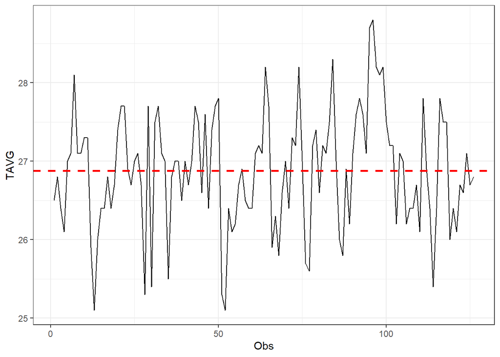

```r
plot1 <- dt1 |> as_tsibble() |>
  ggplot(aes(x = index, y = value)) + geom_line() + theme_bw() +
  geom_hline(yintercept = mean, color = "red", linetype = "dashed", size = 1) +
  xlab("Obs") + ylab("TAVG")
plot1
```

Deret waktu suhu rata-rata (TAVG) pada observasi 125–250 berfluktuasi di sekitar rata-rata sekitar 26,8 tanpa menunjukkan adanya tren naik atau turun yang jelas. Pola yang relatif stabil di sekitar rataan ini mendukung indikasi bahwa data bersifat stasioner dalam rataan.

## Cek stasioner dalam rataan

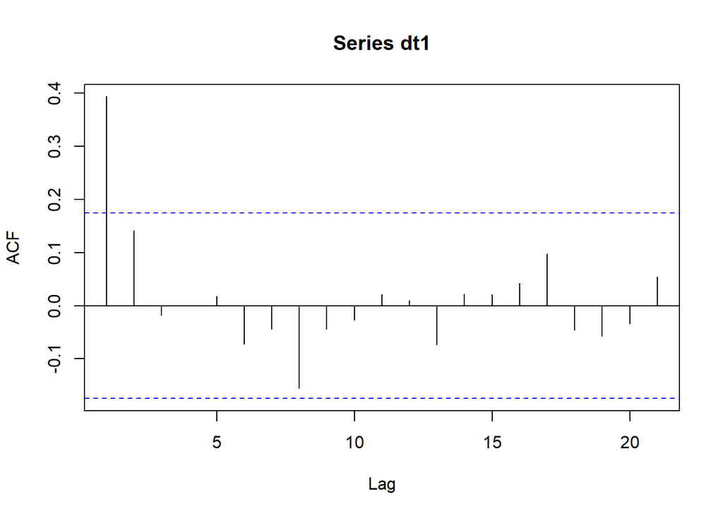

```r
acf(dt1)
```

Plot autokorelasi (ACF) menunjukkan korelasi yang signifikan pada lag kecil kemudian cepat meredam mendekati nol. Pola seperti ini konsisten dengan karakteristik data stasioner, di mana ketergantungan antarobservasi hanya terjadi dalam jangka pendek dan tidak berlanjut panjang.

```r
tseries::adf.test(dt1)
```

```
##
##  Augmented Dickey-Fuller Test
##
## data:  dt1
## Dickey-Fuller = -4.3257, Lag order = 4, p-value = 0.01
## alternative hypothesis: stationary
```

Uji Augmented Dickey-Fuller menghasilkan nilai statistik -4,3257 dengan p-value ≤ 0,05, sehingga hipotesis nol ditolak. Hal ini mengonfirmasi bahwa seri data bersifat stasioner dan tidak memerlukan transformasi differencing untuk mencapai kestasioneran.

## Cek Stasioner dalam Ragam

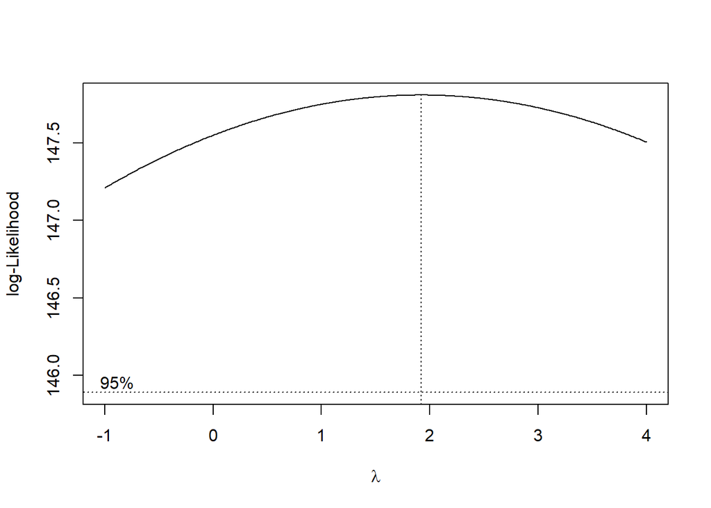

```r
index <- seq(1:126)

# Box-Cox
bc <- boxcox(
  dt1 ~ index,
  lambda = seq(-1, 4, by = 0.01)
)
```

```r
lambda <- bc$x[which.max(bc$y)]
lambda
```

```
## [1] 1.92
```

```r
# Selang kepercayaan 95% untuk lambda
ci_lambda <- bc$x[bc$y > max(bc$y) - 0.5 * qchisq(0.95, 1)]

# Batas bawah dan batas atas
ci_lower <- min(ci_lambda)
ci_upper <- max(ci_lambda)

c(Batas_Bawah = ci_lower, Batas_Atas = ci_upper)
```

```
## Batas_Bawah  Batas_Atas
##          -1           4
```

hasil di atas menunjukkan nilai λ optimum sebesar 1,92 dan selang kepercayaan 95% nilai memiliki batas bawah -1 dan batas atas 4. Selang tersebut memuat nilai satu sehingga dapat dikatakan bahwa data TAVG pada amatan 125-250 stasioner dalam ragam.

# Split Data

```r
n <- length(dt1)
train_size <- floor(0.8 * n)
train <- dt1[1:train_size]
test  <- dt1[(train_size+1):n]
train <- ts(train)
```

data displit dengan proporsi train 80% dan test 20%, selanjutnya akan dilakukan pengecekan stasioneritas pada data train

```r
mean1 <- mean(train, na.rm = TRUE)
mean1
```

```
## [1] 26.918
```

```r
var(train)
```

```
## [1] 0.6095717
```

# Pengecekan Kestasioneran Data Train

```r
plot2 <- train |> as_tsibble() |>
  ggplot(aes(x = index, y = value)) + geom_line() + theme_bw() +
  geom_hline(yintercept = mean1, color = "red", linetype = "dashed", size = 1) +
  xlab("Obs") + ylab("TAVG")
```

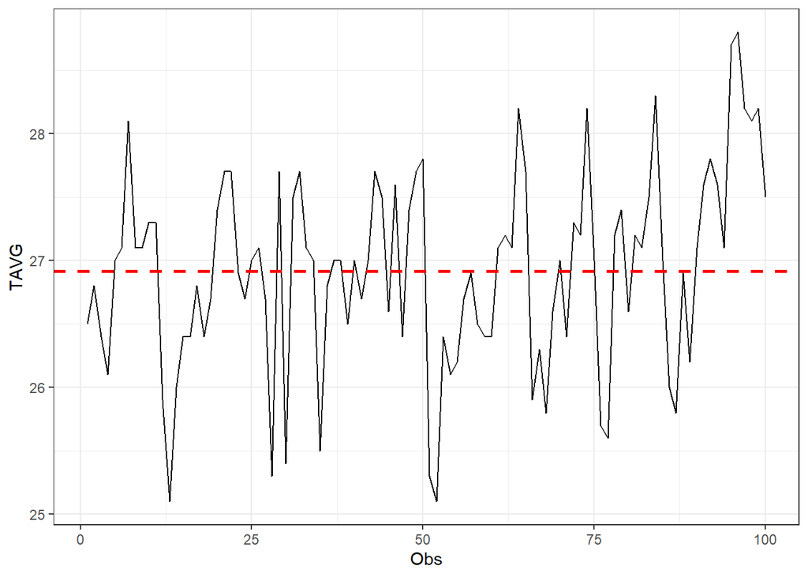

```r
plot2
```

Deret waktu suhu rata-rata (TAVG) pada data train berfluktuasi di sekitar rata-rata sekitar 26,92 tanpa menunjukkan adanya tren naik atau turun yang jelas. Pola yang relatif stabil di sekitar rataan ini mendukung indikasi bahwa data train bersifat stasioner dalam rataan.

## Cek stasioner dalam rataan

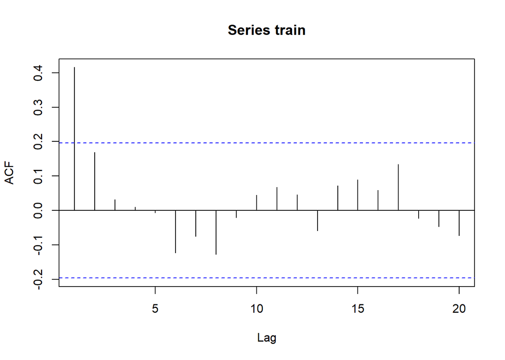

```r
acf(train)
```

Plot autokorelasi (ACF) menunjukkan korelasi yang signifikan pada lag kecil kemudian cepat meredam mendekati nol. Pola seperti ini konsisten dengan karakteristik data stasioner, di mana ketergantungan antarobservasi hanya terjadi dalam jangka pendek dan tidak berlanjut panjang.

```r
tseries::adf.test(train)
```

```
##
##  Augmented Dickey-Fuller Test
##
## data:  train
## Dickey-Fuller = -3.8711, Lag order = 4, p-value = 0.01826
## alternative hypothesis: stationary
```

Uji Augmented Dickey-Fuller menghasilkan nilai statistik -3.8711 dengan p-value 0.01826 ≤ 0,05, sehingga hipotesis nol ditolak. Hal ini mengonfirmasi bahwa seri data bersifat stasioner dan tidak memerlukan transformasi differencing untuk mencapai kestasioneran.

## Cek Stasioner dalam Ragam

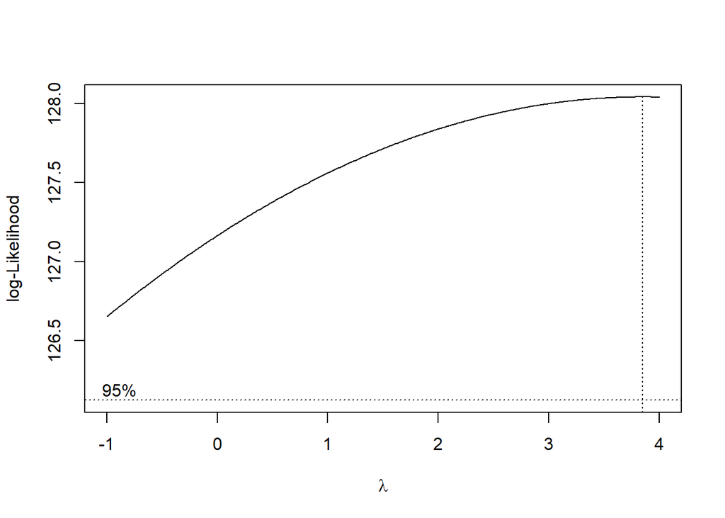

```r
index <- seq(1:(0.8*126))

# Box-Cox
bc2 <- boxcox(
  train ~ index,
  lambda = seq(-1, 4, by = 0.01)
)
```

```r
lambda2 <- bc2$x[which.max(bc2$y)]
lambda2
```

```
## [1] 3.85
```

```r
# Selang kepercayaan 95% untuk lambda
ci_lambda <- bc2$x[bc2$y > max(bc2$y) - 0.5 * qchisq(0.95, 1)]

# Batas bawah dan batas atas
ci_lower <- min(ci_lambda)
ci_upper <- max(ci_lambda)

c(Batas_Bawah = ci_lower, Batas_Atas = ci_upper)
```

```
## Batas_Bawah  Batas_Atas
##          -1           4
```

hasil di atas menunjukkan nilai λ optimum sebesar 3,85 dan selang kepercayaan 95% nilai memiliki batas bawah -1 dan batas atas 4. Selang tersebut memuat nilai satu sehingga dapat dikatakan bahwa data train stasioner dalam ragam.

# Identifikasi Model

## Plot ACF

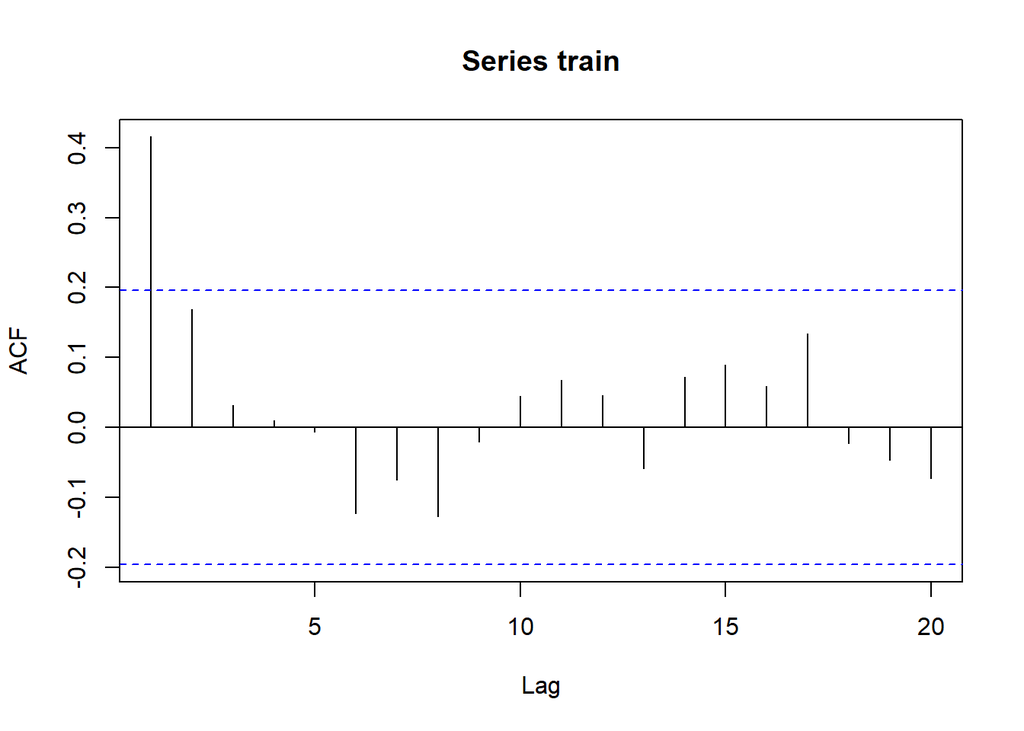

```r
acf(train)
```

## PACF

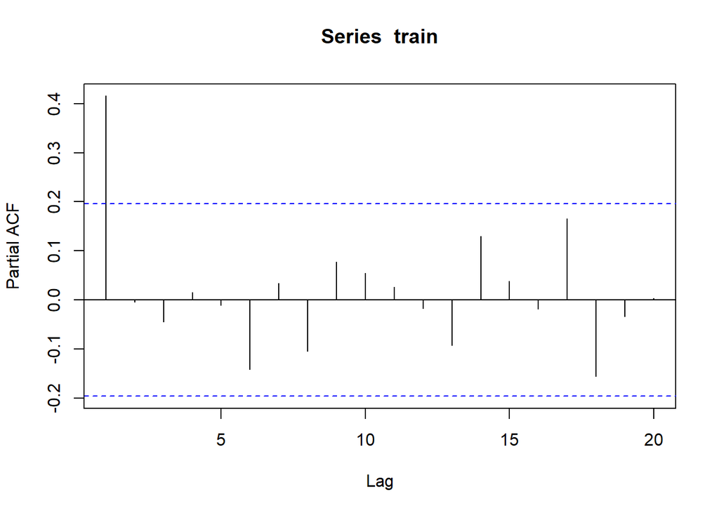

```r
pacf(train)
```

## EACF

```r
eacf(train)
```

```
## AR/MA
##   0 1 2 3 4 5 6 7 8 9 10 11 12 13
## 0 x o o o o o o o o o o  o  o  o
## 1 o o o o o o o o o o o  o  o  o
## 2 o o o o o o o o o o o  o  o  o
## 3 x o o o o o o o o o o  o  o  o
## 4 x o x o o o o o o o o  o  o  o
## 5 o o x o o o o o o o o  o  o  o
## 6 o x o x o o o o o o o  o  o  o
## 7 o x o x o x o o o o o  o  o  o
```

# Pendugaan Parameter Model Tentatif

```r
model.da=Arima(train, order=c(0,0,1),method="ML")
summary(model.da)
```

```
## Series: train
## ARIMA(0,0,1) with non-zero mean
##
## Coefficients:
##          ma1     mean
##       0.3595  26.9174
## s.e.  0.0824   0.0972
##
## sigma^2 = 0.5242:  log likelihood = -108.66
## AIC=223.33   AICc=223.58   BIC=231.14
##
## Training set error measures:
##                       ME      RMSE       MAE         MPE     MAPE      MASE
## Training set 0.001176994 0.7167704 0.5563762 -0.06876164 2.076146 0.8855506
##                    ACF1
## Training set 0.06283482
```

```r
lmtest::coeftest(model.da)
```

```
##
## z test of coefficients:
##
##            Estimate Std. Error  z value  Pr(>|z|)
## ma1        0.359486   0.082391   4.3632 1.282e-05 ***
## intercept 26.917412   0.097188 276.9626 < 2.2e-16 ***
## ---
## Signif. codes:  0 '***' 0.001 '**' 0.01 '*' 0.05 '.' 0.1 ' ' 1
```

## ARIMA (1,1,0)

```r
model1.da=Arima(train, order=c(1,1,0),method="ML")
summary(model1.da)
```

```
## Series: train
## ARIMA(1,1,0)
##
## Coefficients:
##           ar1
##       -0.2945
## s.e.   0.0958
##
## sigma^2 = 0.6518:  log likelihood = -118.83
## AIC=241.66   AICc=241.78   BIC=246.85
##
## Training set error measures:
##                      ME      RMSE       MAE          MPE    MAPE     MASE
## Training set 0.01513896 0.7992153 0.6292901 0.0008065478 2.35244 1.001603
##                     ACF1
## Training set -0.06228319
```

```r
lmtest::coeftest(model1.da)
```

```
##
## z test of coefficients:
##
##      Estimate Std. Error z value Pr(>|z|)
## ar1 -0.294526   0.095843  -3.073 0.002119 **
## ---
## Signif. codes:  0 '***' 0.001 '**' 0.01 '*' 0.05 '.' 0.1 ' ' 1
```

```r
model2.da=Arima(train, order=c(1,0,1),method="ML")
summary(model1.da)
```

```
## Series: train
## ARIMA(1,1,0)
##
## Coefficients:
##           ar1
##       -0.2945
## s.e.   0.0958
##
## sigma^2 = 0.6518:  log likelihood = -118.83
## AIC=241.66   AICc=241.78   BIC=246.85
##
## Training set error measures:
##                      ME      RMSE       MAE          MPE    MAPE     MASE
## Training set 0.01513896 0.7992153 0.6292901 0.0008065478 2.35244 1.001603
##                     ACF1
## Training set -0.06228319
```

```r
lmtest::coeftest(model2.da)
```

```
##
## z test of coefficients:
##
##              Estimate  Std. Error  z value Pr(>|z|)
## ar1        0.41537161  0.20516586   2.0246  0.04291 *
## ma1       -0.00044423  0.22198067  -0.0020  0.99840
## intercept 26.91917062  0.11986746 224.5745  < 2e-16 ***
## ---
## Signif. codes:  0 '***' 0.001 '**' 0.01 '*' 0.05 '.' 0.1 ' ' 1
```

```r
model3.da=Arima(train, order=c(2,0,0),method="ML")
summary(model1.da)
```

```
## Series: train
## ARIMA(1,1,0)
##
## Coefficients:
##           ar1
##       -0.2945
## s.e.   0.0958
##
## sigma^2 = 0.6518:  log likelihood = -118.83
## AIC=241.66   AICc=241.78   BIC=246.85
##
## Training set error measures:
##                      ME      RMSE       MAE          MPE    MAPE     MASE
## Training set 0.01513896 0.7992153 0.6292901 0.0008065478 2.35244 1.001603
##                     ACF1
## Training set -0.06228319
```

```r
lmtest::coeftest(model3.da)
```

```
##
## z test of coefficients:
##
##             Estimate Std. Error  z value  Pr(>|z|)
## ar1       4.1491e-01 9.9526e-02   4.1689 3.061e-05 ***
## ar2       2.2527e-04 1.0054e-01   0.0022    0.9982
## intercept 2.6919e+01 1.1988e-01 224.5599 < 2.2e-16 ***
## ---
## Signif. codes:  0 '***' 0.001 '**' 0.01 '*' 0.05 '.' 0.1 ' ' 1
```

## Ringkasan AIC BIC

```r
model_tentatif <- data.frame(
  Model = c("ARIMA(0,1,1)","ARIMA(1,1,0)","ARIMA(1,1,1)", "ARIMA(2,1,0)"),
  AIC   = c(AIC(model.da),AIC(model1.da),AIC(model2.da), AIC(model3.da)),
  BIC   = c(BIC(model.da),BIC(model1.da),BIC(model2.da), BIC(model3.da))
)

model_tentatif
```

[output not shown]

# Analisis Sisaan

Model terbaik hasil identifikasi kemudian dicek asumsi sisaannya. Sisaan model ARIMA harus memenuhi asumsi normalitas, kebebasan sisaan, dan kehomogenan ragam. Diagnostik model dilakukan secara eksplorasi dan uji formal.

## Eksplorasi Sisaan

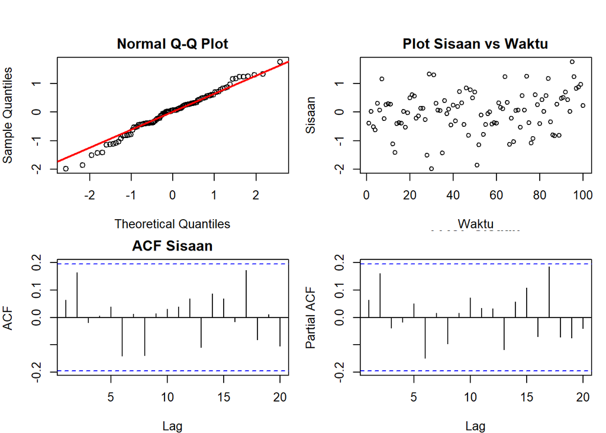

```r
sisaan.da <- model.da$residuals

par(mfrow = c(2,2),
    mar = c(4,4,2,1),
    oma = c(0,0,2,0))

# Q-Q Plot
qqnorm(sisaan.da, main = "Normal Q-Q Plot")
qqline(sisaan.da, col = "red", lwd = 2)

# Plot Sisaan vs Waktu
plot(sisaan.da, type = "p",
     main = "Plot Sisaan vs Waktu",
     xlab = "Waktu", ylab = "Sisaan")

# ACF
acf(sisaan.da, main = "ACF Sisaan")

# PACF
pacf(sisaan.da, main = "PACF Sisaan")
```

## Uji Formal

```r
ks.test(sisaan.da,"pnorm")
```

```
##
##  Asymptotic one-sample Kolmogorov-Smirnov test
##
## data:  sisaan.da
## D = 0.12471, p-value = 0.08916
## alternative hypothesis: two-sided
```

Selain dengan eksplorasi, asumsi tersebut dapat diuji menggunakan uji formal. Pada tahapan ini uji formal yang digunakan untuk normalitas adalah uji Kolmogorov-Smirnov (KS). Hipotesis pada uji KS adalah sebagai berikut.

H0 : Sisaan menyebar normal

H1 : Sisaan tidak menyebar normal

Berdasarkan uji KS tersebut, didapat p-value sebesar 0.08916 yang lebih dari taraf nyata 5% sehingga terima H0. Hal menandakan bahwa sisaan menyebar normal pada taraf nyata 5%. Hal ini sesuai dengan hasil eksplorasi menggunakan plot kuantil-kuantil normal.

```r
Box.test(sisaan.da, type = "Ljung")
```

```
##
##  Box-Ljung test
##
## data:  sisaan.da
## X-squared = 0.40679, df = 1, p-value = 0.5236
```

Selanjutnya akan dilakukan uji formal untuk kebebasan sisaan menggunakan uji Ljung-Box. Hipotesis yang digunakan adalah sebagai berikut.

H0 : Sisaan saling bebas

H1 : Sisaan tidak tidak saling bebas

Berdasarkan uji Ljung-Box tersebut, didapat p-value sebesar 0.5236 yang lebih besar dari taraf nyata 5% sehingga gagal tolak dan menandakan bahwa sisaan saling bebas pada taraf nyata 5%. Hal ini berbeda sama dengan hasil eksplorasi.

```r
Box.test((sisaan.da)^2, type = "Ljung")
```

```
##
##  Box-Ljung test
##
## data:  (sisaan.da)^2
## X-squared = 6.5711, df = 1, p-value = 0.01036
```

Hipotesis yang digunakan untuk uji kehomogenan ragam adalah sebagai berikut.

H0 : Ragam sisaan homogen

H1 : Ragam sisaan tidak homogen

Berdasarkan uji Ljung-Box terhadap sisaan kuadrat tersebut, didapat p-value sebesar 0.01036 yang kurang dari taraf nyata 5% sehingga tolaaak H0 dan menandakan bahwa ragam sisaan tidak homogen pada taraf nyata 5%.

```r
t.test(sisaan.da, mu = 0, conf.level = 0.95)
```

```
##
##  One Sample t-test
##
## data:  sisaan.da
## t = 0.016339, df = 99, p-value = 0.987
## alternative hypothesis: true mean is not equal to 0
## 95 percent confidence interval:
##  -0.1417621  0.1441161
## sample estimates:
##   mean of x
## 0.001176994
```

Terakhir, dengan uji-t, akan dicek apakah nilai tengah sisaan sama dengan nol. Hipotesis yang diujikan sebagai berikut.

H0 : nilai tengah sisaan sama dengan 0

H1 : nilai tengah sisaan tidak sama dengan 0

Berdasarkan uji-t tersebut, didapat p-value sebesar 0.987 yang lebih besar dari taraf nyata 5% sehingga gagal tolak dan menandakan bahwa nilai tengah sisaan sama dengan nol.